# Verosimilitud

# Función de verosimilitud

## Caso: $X \sim exp(\lambda)$

Definimos las siguientes funciones de verosimilitud:

- Observaciones exactas: $L = \prod_{j} f_{X}(x_{j})$
- Observaciones exactas y censuradas por derecha (la más común): $L = \prod_{j \in D} f_{X}(x_{j}) \prod_{j \in R}S_{X}(x_{j}).$
- Observaciones exactas y censuradas por derecha e izquierda: $L = \prod_{j \in D} f_{X}(x_{j}) \prod_{j \in R}S_{X}(x_{j}) \prod_{j \in L}F_{X}(x_{j}).$
- Obervaciones exactas y censuradas por derecha e izquierda pero también truncadas por la izq: $L = \prod_{j \in D} f_{X}(x_{j}) \prod_{j \in R}S_{X}(x_{j}) \prod_{j \in L}F_{X}(x_{j}) \prod_{j \in T_{lD}}\frac{f_X(x_{j})}{S_{X}(u_{j})} \prod_{j \in T_{lR}}\frac{S_X(x_{j})}{S_{X}(u_{j})} \prod_{j \in T_{lL}}\frac{F_X(x_{j})}{F_{X}(u_{j})}.$

Las verosimilitudes se harán simulando una funcion exponencial.

```r
#funciones de verosimilitud

#Obs exactas
lik1<-function(lam,tt){
  n<-length(tt)
  out<-1
  for (i in 1:n){
    out<-out*dexp(tt[i],lam)
  }
  out
}

#Obs excatas + censura por derecha
#(delta=1, exacta; delta=0, censura der.)
lik2<-function(lam,tt,delta){
  n<-length(tt)
  out<-1
  for (i in 1:n){
    out<-out*(dexp(tt[i],lam)^delta[i])*((1-pexp(tt[i],lam))^(1-delta[i]))
  }
  out
}
#Obs excatas + censura por derecha e izquierda
#(delta=1,exacta; delta=0,cens der; delta=2,cens izq)
lik3<-function(lam,tt,delta){
  n<-length(tt)
  out<-1
  for (i in 1:n){
    if (delta[i]==1) {out<-out*dexp(tt[i],lam)}
    if (delta[i]==0) {out<-out*(1-pexp(tt[i],lam))}
    if (delta[i]==2) {out<-out*pexp(tt[i],lam)}
  }
  out
}
#Obs excatas + cens der e izq + trunc izq
#(delta=1,exacta; delta=0,cens der; delta=2,cens izq)
#(u = 0, NO hay truncamiento, u != 0, truncamiento)
lik4<-function(lam,tt,delta,u=rep(0,times=length(tt))){
  n<-length(tt)
  out<-1
  for (i in 1:n){ if (is.na(tt[i])==FALSE) {
    if (delta[i]==1) {out<-out*dexp(tt[i],lam)/(1-pexp(u[i],lam))}
    if (delta[i]==0) {out<-out*(1-pexp(tt[i],lam))/(1-pexp(u[i],lam))}
    if (delta[i]==2) {out<-out*(pexp(tt[i],lam)-pexp(u[i],lam))/(1-pexp(u[i],lam))}
  }
  }
  out
}
```

# Ejemplos

```r
#seed
set.seed(42)

#Ex1
lam0<-1.5
n<-100 #number of simulations
x<-rexp(n,lam0) #sim

#Censura por derecha (aleatoria)
lamc<-1.5 #(no necesariamente tiene que ser la misma lambda de censura)
cen<-rexp(n,lamc)
tt<-ifelse(x<=cen,x,cen)
delta<-x
delta<-ifelse(x<=cen,1,0)
propc<-1-sum(delta)/n #rate of censoring

#Censura por izquierda
lamci<-0.5 #no tiene que ser misma lambda
ceni<-rexp (n,lamci)
tti<-ifelse(x>=ceni,x,ceni)
deltai<-x
deltai<-ifelse(x>=ceni,1,2)

#Truncamiento izquierda
u<-seq(0.5,0.5,length.out=n)
ttrunc<-ifelse(tt>=u,tt,NA)
```

Vamos a ver como con distintas lambdas la verosimilitud va cambiando y veremos donde es donde la “lambda” está y se comparará con el verdadero valor de $\lambda_{0}$.

```r
#Evaluacion
m<-100
lam<-seq(0,4,,m) #distintas lambdas

#likelihood
y1<-lik1(lam,x) #exact observations
y2<-lik2(lam,tt,delta) #exact and right censored
y3<-lik4(lam,ttrunc,delta,u) #truncated by left

#print
par(mfrow=c(1,1))
#ikelihoods
plot(lam,y1/max(y1),type="l")
lines(lam,y2/max(y2),col=2,lty=2)
```

```r
lines(lam,y3/max(y3),col=3,lty=3)
#real lambda
abline(v=lam0,col=4)
```

```r
pos<-order(y1)[m]
abline(v=lam[pos],col=1,lty=1)
pos<-order(y2)[m]
abline(v=lam[pos],col=2,lty=1)
```

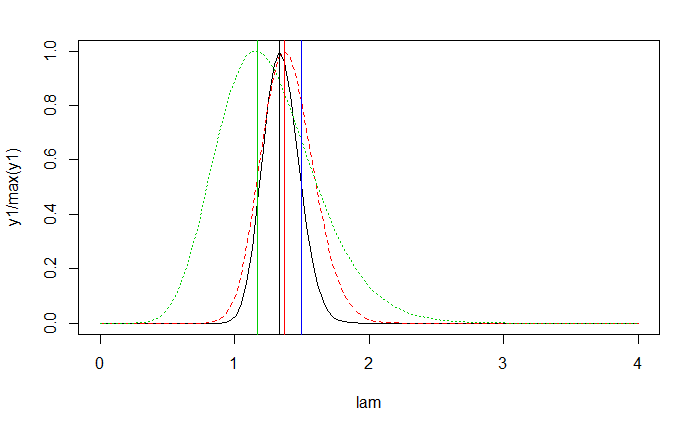

```r
pos<-order(y3)[m]
abline(v=lam[pos],col=3,lty=1)
```

## Ejemplo 2: Efecto de deshechar la censura

Censura será el color

```r
#Evaluacion
lam<-seq(0,4,,m)

#likelihood with and without censoring
y1<-lik2(lam,tt[delta==1],delta[delta==1]) #without censoring
y2<-lik2(lam,tt,delta) #with censoring

par(mfrow=c(1,1))
plot(lam,y1/max(y1),type="l", col = 6)
lines(lam,y2/max(y2),col=2,lty=1)
```

```r
abline(v=lam0,col=4) #true value of lambda

pos<-order(y1)[m]
abline(v=lam[pos],col=6,lty=1)
```

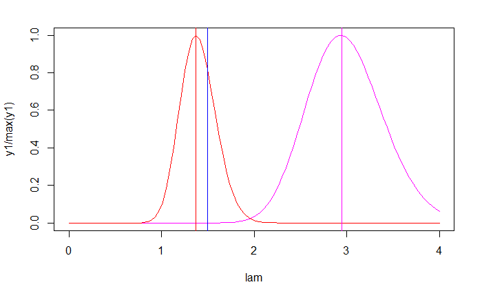

```r
pos<-order(y2)[m]
abline(v=lam[pos],col=2,lty=1)
```

**NOTA**:

- Si el tamaño de muestra es muy grande, quitar o no la censura en escencia no afecta (ley de los grandes números).
- Quitar censura en este caso sobrestima el modelo, además aumenta la variabilidad de la estimación (ver grueso de la campana).

## Ejemplo 3:

Verosimilitud para datos exactos, otra para censurados por derecha y otra para censurados por izquierda (cyan)

```r
#cbind(x,cen,tt,delta,ceni,tti,deltai)
#Evaluacion
lam<-seq(0,4,,m)
y1<-lik1(lam,x)
y2<-lik2(lam,tt,delta)
y3<-lik3(lam,tti,deltai)
par(mfrow=c(1,1))
plot(lam,y1/max(y1),type="l")
lines(lam,y2/max(y2),col=2,lty=1)
```

```r
lines(lam,y3/max(y3),col=5,lty=1)
abline(v=lam0,col=4)
```

```r
pos<-order(y1)[m]
abline(v=lam[pos],col=1,lty=1)
pos<-order(y2)[m]
abline(v=lam[pos],col=2,lty=1)
```

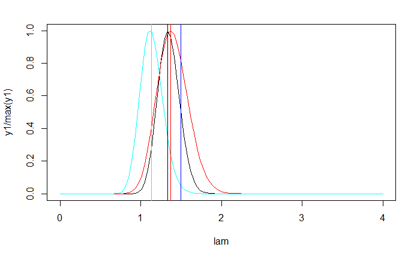

```r
pos<-order(y3)[m]
abline(v=lam[pos],col=5,lty=1)
```

## Ejemplo: Doble censura

```r
set.seed(42)
# new simulation
#Ejemplo 4 (doble censura)
lam0<-2
n<-50
x<-rexp(n,lam0)
#Censura por derecha
lamc<-0.5
cen<-rexp(n,lamc)
#Censura por izquierda
lamci<-3
ceni<-rexp(n,lamci)
#Doble censura
tt<-ifelse(x>=ceni,x,ceni) #censura por derecha (T > C)
deltai<-ifelse(x>=ceni,1,2)
delta<-deltai
delta[deltai==1]<-ifelse(tt[deltai==1]<=cen[deltai==1],1,0)
tt[deltai==1]<-ifelse(x[deltai==1]<=cen[deltai==1],x[deltai==1],cen[deltai==1]) #poner la censura por izq

#tabla de censura
# prop.table(table(delta))


#Evaluacion
m<-100
lam<-seq(0,5,,m)
y1<-lik1(lam,x)
y2<-lik3(lam,tt,delta)
par(mfrow=c(1,1))
plot(lam,y1/max(y1),type="l")
lines(lam,y2/max(y2),col = 'orange',lty=1)
```

```r
abline(v=lam0,col=4)
pos<-order(y1)[m]
abline(v=lam[pos],col=1,lty=1)
```

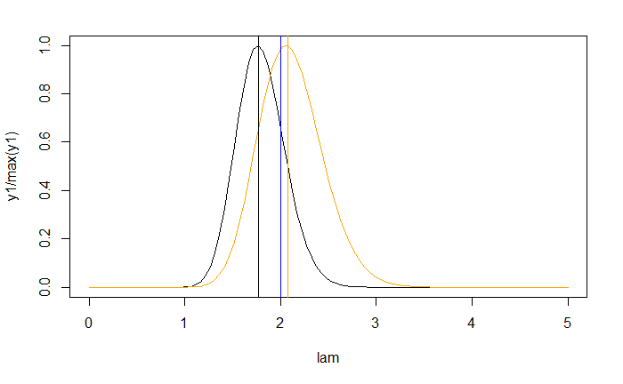

```r
pos<-order(y2)[m]
abline(v=lam[pos],col='orange',lty=1)
```

## Otros ejemplos: Distribuciones Weibull

En este caso, como la distribución Weibull tiene dos parámetros $a,b$ de localización y escala, la verosimilitud se verá en forma de contornos y no por densidades.El programa R tiene la densidad Weibull como (locoalización y escala):

$$f_{X}(x) = \frac{a}{b}(\frac{x}{b})^{a-1} e^{-(\frac{x}{b})^{a}}.$$

Mientras que nosotros tenemos la función de densidad definida de la siguiente manera ($\lambda$ es la tasa):
$$f_{X}(x) = \lambda \alpha x^{\alpha -1} e^{-\lambda t^{\alpha}}.$$

Por lo que en este caso:

- $a = \alpha.$
- $\lambda = \frac{1}{b^{a}}.$

Función de verosimilitud para obs exactas, censuradas por derecha e izquierda y truncadas por la izquierda:

```r
#Obs excatas + cens der e izq + trunc izq
#(delta=1,exacta; delta=0,cens der; delta=2,cens izq)
#verosimilitu para distintas a y b, por eso es una matriz
lik4w<-function(a,b,tt,delta,u=rep(0,times=length(tt))){
  m<-length(a)
  outm<-matrix(NA,nrow=m,ncol=m)
  for (j in 1:m){
      n<-length(tt)
      out<-1
      for (i in 1:n){ if (is.na(tt[i])==FALSE) {
        if (delta[i]==1) {out<-out*dweibull(tt[i],a,b[j])/(1-pweibull(u[i],a,b[j]))}
        if (delta[i]==0) {out<-out*(1-pweibull(tt[i],a,b[j]))/(1-pweibull(u[i],a,b[j]))}
        if (delta[i]==2) {out<-out*(pweibull(tt[i],a,b[j])-pweibull(u[i],a,b[j]))/(1-pweibull(u[i],a,b[j]))}
      }
    }
    out
    outm[,j]<-out #append
  }
  return(outm)
}
```

Simulación para casos exactos, censura por derecha y truncamiento por izquierda.

```r
#seed
set.seed(8)
#Ejemplos W
alf0<-2
lam0<-1
#cahnge of parameter
a0<-alf0
b0<-lam0^(-1/a0)

# Simulation
n<-50
x<-rweibull(n,a0,b0)
#censura por derecha
lamc<-2
cen<-rexp(n,lamc)
tt<-ifelse(x<=cen,x,cen)
delta<-x
delta<-ifelse(x<=cen,1,0)
#truncamiento izquierda
u<-seq(0.5,0.5,length.out=n)
ttrunc<-ifelse(tt>=u,tt,NA)

#Evaluacion
m<-100
a<-seq(0.2,3.8,,m)
b<-seq(0.2,3.8,,m)

#likelihood
y1<-lik4w(a,b,x,seq(1,1,,n)) #like a rep, delta = 1 always, #exact
y2<-lik4w(a,b,tt,delta) #censored
y3<-lik4w(a,b,ttrunc,delta,u) #censored and trunced

#plots
par(mfrow=c(1,1))

# exact likelihood
contour(x = a,y = b, z = y1,col=1)
pos<-which(y1==max(y1),arr.ind=TRUE)
points(a[pos[1]],b[pos[2]],col=6,pch=18, cex = 1)
```

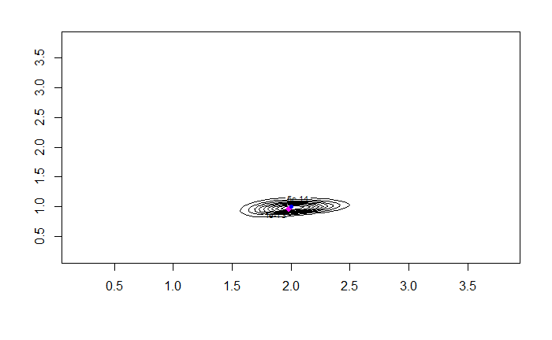

```r
# print(c(a[pos[1]],b[pos[2]]))
points(a0,b0,col=4,pch=20)
```

```r
# censored likelihood
contour(x = a,y = b, z= y2,col=2)
pos<-which(y2==max(y2),arr.ind=TRUE)
points(a[pos[1]],b[pos[2]],col=2,pch=18, cex = 1)
```

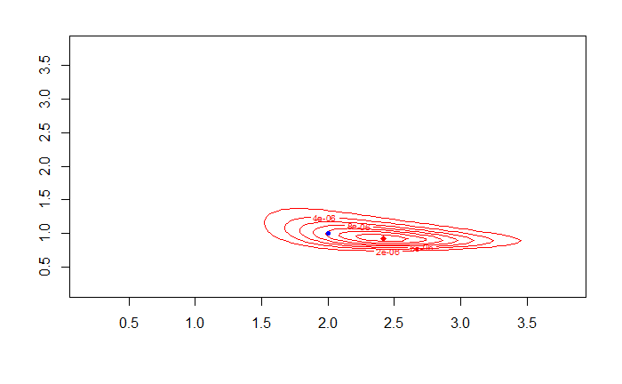

```r
# print(c(a[pos[1]],b[pos[2]]))
points(a0,b0,col=4,pch=20)
```

```r
# truncated likelihood
contour(x = a,y = b,z = y3,col=3)
pos<-which(y3==max(y3),arr.ind=TRUE)
points(a[pos[1]],b[pos[2]],col=3,pch=15)
```

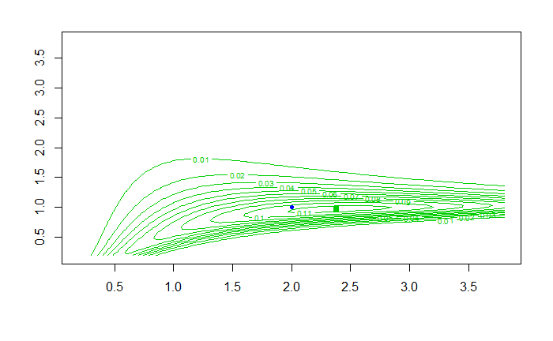

```r
# print(c(a[pos[1]],b[pos[2]]))
points(alf0,lam0,col=4,pch=20)
```

REPRODUCIR CONTORNOS EN MISMA GRAFICA

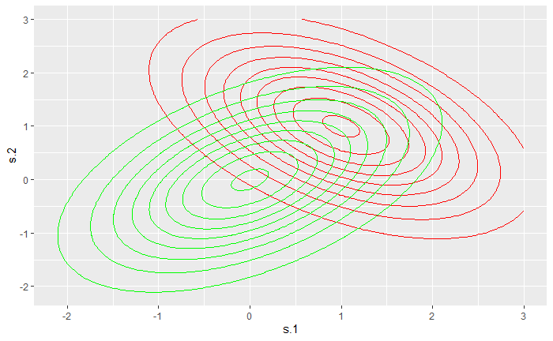

```r
library(MASS)
library(ggplot2)
# first contour
m <- c(.0, -.0)
sigma <- matrix(c(1,.5,.5,1), nrow=2)
data.grid <- expand.grid(s.1 = seq(-3, 3, length.out=200), s.2 = seq(-3, 3, length.out=200))
q.samp <- cbind(data.grid, prob = mvtnorm::dmvnorm(data.grid, mean = m, sigma = sigma))

plot1 <- ggplot(q.samp, aes(x = s.1, y = s.2, z = prob)) +
  stat_contour(color = 'green')

# second contour
m1 <- c(1, 1)
sigma1 <- matrix(c(1,-.5,-.5,1), nrow=2)
set.seed(10)
data.grid1 <- expand.grid(s.1 = seq(-3, 3, length.out=200), s.2 = seq(-3, 3, length.out=200))
q.samp1 <- cbind(data.grid1, prob = mvtnorm::dmvnorm(data.grid1, mean = m1, sigma = sigma1))
plot2 <- ggplot(q.samp1, aes(x = s.1, y = s.2, z = prob)) +
  stat_contour(color = 'red')

ggplot(q.samp1, aes(x = s.1, y = s.2, z = prob)) +
  stat_contour(color = 'red') +
  stat_contour(data = q.samp, aes(x = s.1, y = s.2, z = prob), color = 'green')
```